# Tech Bros to Cowboys: How Much Better Off Are Californians Who Move to Texas?

Ken Xiong

Artem Senchev

Sam Der

Pedro Jose Palacios

2026-08-16

## Abstract

Hundreds of thousands of Californians have left for Texas since the pandemic, and the reason they give is almost always the same one: things cost less there. We ask the obvious follow-up question. Does the move actually pay?

Using American Community Survey microdata for California and Texas from 2021 to 2023 (n = 981,006 working-age adults in 547,600 households), we compare recent California-to-Texas movers against Californians who stayed, holding age, sex, race and ethnicity, nativity, education, and household composition fixed. Movers come out **10.1% better off** in material terms — what their family income actually buys where they now live (95% CI 3.7% to 16.9%, p = 0.002). A second measure built on entirely different definitions, the Supplemental Poverty Measure, puts the advantage at 17.9%.

The advantage is invisible in official statistics. Measured against the federal poverty threshold — the same dollar figure in San Francisco as in El Paso — the same comparison yields no detectable difference (-3.9%, p = 0.19). The gain is real but consists entirely of purchasing power, which the official measure is designed not to see.

These are descriptive comparisons. Movers choose to move, on characteristics this data cannot observe, and nothing here identifies a causal effect of moving on anyone.

**Keywords:** interstate migration, cost of living, material living standards, poverty measurement, American Community Survey

## 1. Does the move pay?

California’s median home price passed $900,000 in 2026, and $1.4 million in the Bay Area (California Association of Realtors, 2026). Texas’s statewide median sat near $340,000 (Mayer, 2026). That gap has driven one of the largest interstate migration flows in the country (Parker et al., 2023), and it comes with an implicit promise: the same paycheck goes further in Texas, so the people making the move end up ahead.

It is a promise worth testing, and it is not obvious it should hold. Movers might be trading a high salary for a lower one. They might be arriving into jobs that pay Texas wages rather than keeping California ones. The cost saving is real, but so is the possibility that income falls to meet it.

This paper measures the net result. We compare Californians who moved to Texas within the past year against Californians who did not move, matched on the demographics that ordinarily drive income, and we ask how much further their money goes.

The answer is that the move pays — by about 10% — and that you cannot see it in the official poverty statistics, for a reason we return to in Section 6.

## 2. Data

**Microdata.** IPUMS USA (Ruggles et al., 2025) one-year ACS samples for 2021, 2022, and 2023, restricted to California and Texas. We keep working-age adults (25–64) living in households rather than group quarters. The 2024 wave is dropped because a component we use for robustness is unpublished for that year, and we prefer every model to run on identical rows rather than let each specification silently choose its own sample.

| Step | Rows remaining | Removed |
| --- | --- | --- |
| Raw extract (CA + TX, 2021–2024) | 2,657,979 | — |
| Drop the 2024 wave | 1,984,999 | 672,980 |
| Keep ages 25–64 | 1,023,275 | 961,724 |
| Drop group quarters | 981,006 | 42,269 |
| **Analysis sample** | **981,006** |  |

Four further exclusion checks — third-state arrivals, people outside the poverty universe, survey years without a published price index, and missing covariates — each remove zero rows, because the extract was already case-selected to this universe. They remain in the pipeline so a differently built extract cannot quietly change the sample without the attrition table showing it.

**Prices.** BEA Regional Price Parities, table SARPP, all-items index, national average = 100 (U.S. Bureau of Economic Analysis, 2026). In 2023 California stands at 112.20 and Texas at 97.14: a dollar in Texas buys about 15% more than the same dollar in California.

**Who counts as a mover.** `MIGPLAC1` records state of residence one year before the survey. Crossing it with current state yields six groups. The comparison group is Californians in the *same house* as a year ago; people who moved within California are tracked separately rather than folded into the baseline, which matters because moving itself is correlated with income.

| Group | Meaning | n |
| --- | --- | --- |
| `CA_stay` | In California, same house — **comparison group** | 524,268 |
| `CA_to_CA` | Moved within California | 50,763 |
| **`CA_to_TX`** | **California → Texas** | **1,482** |
| `TX_stay` | In Texas, same house | 364,801 |
| `TX_to_TX` | Moved within Texas | 39,101 |
| `TX_to_CA` | Texas → California | 591 |

About 400 to 540 Californians per wave show up as recent Texas arrivals. That is a real constraint: it widens the confidence interval on the central estimate and rules out slicing movers further by metro, industry, or income band.

## 3. Measuring “better off”

“Better off” has to mean something specific. We use **income relative to need**: family income divided by the poverty threshold for a family of that size and composition, so 1.0 sits exactly at the line and 4.0 means four times it. This handles the fact that a $90,000 income means something different to a single adult than to a family of five.

The question is which threshold. The federal poverty line is the same nominal figure in every state, which means a comparison built on it holds purchasing power constant by construction — precisely the thing we are trying to measure. So our primary measure prices the threshold to where the family actually lives: the national threshold scaled by that state’s price index. Income covering three times the local cost of need in Texas is what we mean by “three times better than the line.”

Concretely, the price-adjusted ratio is the official ratio *divided* by RPP/100. Higher prices mean a given income covers less local need. Reversing this — multiplying — would apply California’s high prices as a bonus instead of a cost and invert every comparison in the paper, so the pipeline asserts that California’s mean ratio falls after adjustment and refuses to write a sample that fails the check.

We report three measures throughout:

- **Price-adjusted (primary):** income relative to the locally-priced threshold.
- **Official:** income relative to the national threshold, unadjusted.
- **Supplemental Poverty Measure (robustness):** the Census SPM, which redefines resources *and* threshold at once — taxes, benefits, work expenses, and geography. Because it moves several things simultaneously it cannot isolate the price effect, which is exactly why it is a check on the conclusion rather than the basis for it.

Ratios enter the models in logs, floored at 0.10 because the bottom code absorbs zero and negative family income, so coefficients read as percentage differences.

## 4. Who moves, and why it must be controlled for

Movers are not a random draw from stayers, and the differences all run in the direction that would flatter Texas if left alone.

|  | CA stay | CA→CA | **CA→TX** | TX stay |
| --- | --- | --- | --- | --- |
| Mean age | 44.3 | 38.3 | **39.6** | 44.2 |
| BA or more | 36.9% | 48.1% | **47.8%** | 34.6% |
| Married | 56.2% | 44.1% | **59.2%** | 61.7% |
| Family size | 3.33 | 2.75 | **2.85** | 3.18 |

*Weighted by `PERWT`.*

Californians who left for Texas are nearly five years younger than those who stayed and **eleven percentage points more likely to hold a bachelor’s degree**. In this sample a degree is associated with 90.5% higher income relative to need, so that education gap alone could manufacture a large apparent “Texas effect” in an uncontrolled comparison.

Notably, they look almost identical on education to people who moved *within* California (47.8% against 48.1%). Whatever selects people into moving is mostly about moving, not about Texas.

One thing does separate cross-state movers from local ones: they are *more* likely to be married (59.2%) than stayers (56.2%), while within-state movers are markedly less likely (44.1%). Leaving the state looks like a household decision in a way that moving across town does not.

## 5. Results

We estimate

log (income-to-needs)<sub>*i*</sub> = *β*<sub>0</sub> + *β*<sup>′</sup>Migration<sub>*i*</sub> + *γ*<sup>′</sup>Demographics<sub>*i*</sub> + *δ*<sup>′</sup>Education<sub>*i*</sub> + *θ*<sup>′</sup>Household<sub>*i*</sub> + *ε*<sub>*i*</sub>

by weighted least squares using ACS person weights, with standard errors clustered on household. Clustering is not optional: the ACS samples entire households, income relative to need is a family-level measure, and 79.7% of people in our sample share a household with another sampled adult.

### 5.1 How much better off

Adding controls in blocks separates the part of the gap that is about Texas from the part that is about who moves.

| Specification | CA→TX advantage | *R*<sup>2</sup> |
| --- | --- | --- |
| No controls | +18.1% | 0.002 |
| + demographics (age, sex, race, nativity) | +17.3% | 0.059 |
| + education | +12.0% | 0.127 |
| + household composition | **+10.1%** | 0.155 |

Demographics barely dent it. **Education is the single largest correction**, taking the estimate from +17.3% to +12.0%, exactly as Section 4 predicts. Household composition removes another two points. In total, **roughly 45% of the raw mover advantage is composition rather than location.**

What remains is the headline:

> Compared with Californians of the same age, sex, race and ethnicity, nativity, education, marital status, and family size who stayed put, recent California-to-Texas movers have income relative to need **10.1% higher** (95% CI 3.7% to 16.9%, p = 0.002).

To put that in concrete terms: a family sitting at three times the poverty line gains purchasing power worth about **three-tenths of a poverty threshold per year** by making the move — not a transformation, but not trivial either.

The Supplemental Poverty Measure, built on a different definition of both resources and needs, puts the advantage at **+17.9%** (95% CI 10.4% to 25.9%, p < 0.001) — same direction, larger magnitude, from a measure sharing almost nothing with the primary one.

### 5.2 Does it survive scrutiny?

**Movers who join an established household.** Migration is recorded per person, but income relative to need is a family measure, so a mover moving in with people already there is credited with the household’s resources. 16.7% of California-to-Texas movers are in such a household. Excluding them moves the estimate from +10.1% to **+8.1%** — a real attenuation, worth reporting, and not enough to overturn the finding.

**The comparison group.** Californians who moved *within* California are statistically indistinguishable from Californians who did not move (+0.05%, n.s.). Moving per se does not produce the advantage; moving to a cheaper state does.

**The reverse flow.** The 591 Texans who moved to California show -2.6%, not statistically significant. The point estimate has the expected sign but the group is far too small to support a claim.

## 6. Why the official numbers miss this

Run the identical comparison against the unadjusted federal poverty threshold and the result disappears: **-3.9%, p = 0.19**, a confidence interval from -9.5% to +2.0% that comfortably contains zero. On the official measure, California-to-Texas movers are not detectably different from Californians who stayed.

Both numbers are correct. They differ because the entire gain is purchasing power, and the federal threshold is the same dollar figure everywhere by design. A statistic built that way cannot register the one economic fact that motivates the move. This is not a novel critique — Jolliffe (2006) showed two decades ago that cost-of-living adjustments reshuffle which places look poorest — but the California-to-Texas corridor is an unusually clean demonstration of the stakes.

| Group | Official | Price-adjusted |
| --- | --- | --- |
| `TX_stay` (n = 364,801) | **-5.6%** (*p* ≈ 10<sup>−97</sup>) | **+8.2%** (*p* ≈ 10<sup>−183</sup>) |
| `TX_to_TX` (n = 39,101) | -10.1% (*p* ≈ 10<sup>−53</sup>) | +3.0% (p < 0.001) |

Texans in the same home as a year earlier look 5.6% *worse off* than comparable Californians on the official line and 8.2% *better off* once each family’s threshold reflects local prices. Both estimates are precise beyond any plausible sampling noise. The price gap between these states is not a rounding-error adjustment; it is large enough to invert the ranking of two of the largest populations in the country.

That is the context in which the 10.1% mover advantage should be read: not as a fragile artifact of a measurement choice, but as a modest consequence of a price gap so large it flips the comparison for everyone else too.

Figure 1 shows all six groups under both thresholds.

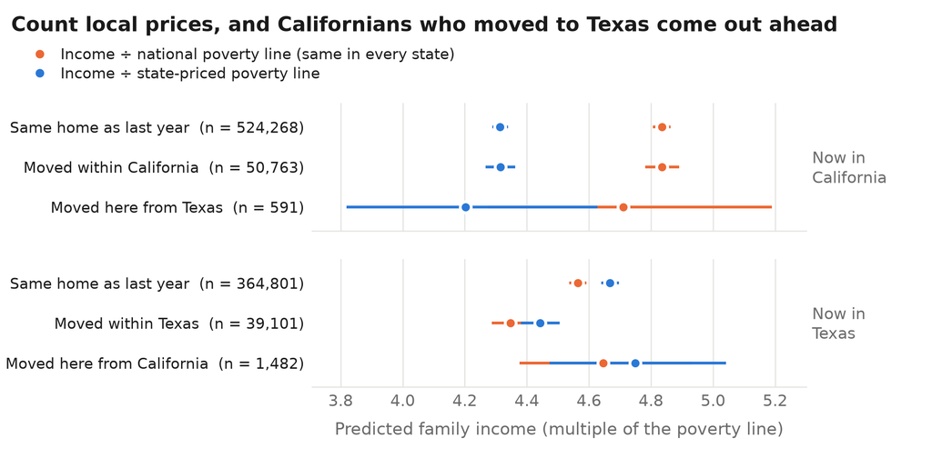

Predicted family income for each migration group as a multiple of the poverty line, from the full specification. Both series use the same incomes and differ only in the line they divide by: orange the national line, identical in every state; blue that line scaled to state prices, 12% higher in California and 3% lower in Texas in 2023. Points are predictions for a reference adult; bars are 95% confidence intervals, widest for the two small cross-state mover groups.

## 8. Reproducibility

The full pipeline is public at https://github.com/artemsenchev/ca-tx-mqol, licensed MIT for code and CC BY 4.0 for this text. The IPUMS extract cannot be redistributed under its terms; the repository documents how to rebuild an equivalent extract from a free account, and every other input is included.

The analysis was originally implemented in R and independently reimplemented in Python. The two agree to floating-point precision — the largest discrepancy across all model coefficients is 7.5 × 10<sup>−11</sup> relative, and 1.3 × 10<sup>−12</sup> for clustered standard errors — and that parity check runs as part of the test suite. Every figure and number in this paper is generated by a script rather than transcribed by hand.

## References

California Association of Realtors. (2026). *June Home Sales and Price Report — car.org*. https://www.car.org/aboutus/mediacenter/newsreleases/2026releases/june2026sales.

Jolliffe, D. (2006). Poverty, prices, and place: How sensitive is the spatial distribution of poverty to cost of living adjustments? *Economic Inquiry*, *44*(2), 296–310. https://doi.org/10.1093/ei/cbj016

Mayer, Y. (2026). *Texas Housing Insight | July 2026 | Texas Real Estate Research Center — trerc.tamu.edu*. https://trerc.tamu.edu/reports/texas-housing-insight-july-2026/.

Parker, P., Behle, B., & Feingold, L. (2023). *California Dreaming: Moving to Texas*. https://abcotvdata.github.io/ca-moving-to-texas/index.html

Ruggles, S., Flood, S., Sobek, M., Backman, D., Cooper, G., Drew, J. A. R., Richards, S., Rodgers, R., Schroeder, J., & Williams, K. C. W. (2025). *IPUMS USA: Version 16.0*. [dataset]; IPUMS. https://doi.org/10.18128/D010.V16.0

U.S. Bureau of Economic Analysis. (2026). *Regional price parities by state (table SARPP), “RPPs: All items”*. https://apps.bea.gov/itable/.